# Uniswap UNI token transactions analysis

Timothée Henry

September 22nd, 2020

# Objective

Objective: analyze Ethereum **UNI token transactions**. The UNI token was introduced on 17th Septembre 2020 Refer to the Uniswap blog post for details: https://uniswap.org/blog/uni/  
The objective of this analysis is to get a better understanding of the market for UNI tokens. Question 1: who are the main holders? Question 2: what percentage of the air drop was redeemed so far? Question 3: did the receivers of air drop keep their tokens? Question 4: which are the main exchanges? Question 5: who are the main buyers and sellers? Question 6: what is driving the price?

# Data source

All data was downloaded using BigQuery with the following queries:

To get token transfers on token UNI (0x1f9840a85d5af5bf1d1762f925bdaddc4201f984) https://etherscan.io/address/0x1f9840a85d5af5bf1d1762f925bdaddc4201f984

```
SELECT * FROM bigquery-public-data.crypto_ethereum.token_transfers
WHERE token_address = "0x1f9840a85d5af5bf1d1762f925bdaddc4201f984"
```

and to get swaps on the ETH-UNI Uniswap exchange (contract 0xd3d2e2692501a5c9ca623199d38826e513033a17) https://uniswap.info/pair/0xd3d2e2692501a5c9ca623199d38826e513033a17 https://etherscan.io/address/0xd3d2e2692501a5c9ca623199d38826e513033a17

```
SELECT * FROM blockchain-etl.ethereum_uniswap.UniswapV2Pair_event_Swap
where contract_address = "0xd3d2e2692501a5c9ca623199d38826e513033a17"
```

# Data analysis

```r
require(data.table)
library(zoo)
t = fread("/Users/henry/Desktop/perso/eth/uniswap/uniswap/uni_transactions_22sep.csv")
s = fread("/Users/henry/Desktop/perso/eth/uniswap/uniswap/uni_swaps_22sep.csv")
```

```r
# convert time
s[, date_time_str := substr(block_timestamp, 1, 16)]
#t[, date_time := strptime(date_time_str, "%Y-%m-%d %H:%M")]
s[, date_time := as.POSIXct(date_time_str, "%Y-%m-%d %H:%M", tz = "GMT")]
s = s[order(date_time)]
s[, amount0In := as.numeric(amount0In) / 1e18]
s[, amount1In := as.numeric(amount1In) / 1e18]
s[, amount0Out := as.numeric(amount0Out) / 1e18]
s[, amount1Out := as.numeric(amount1Out) / 1e18]
s = s[, list(date_time, amount0In, amount1In, amount0Out, amount1Out)]

# deduce UNI/ETH conversion rate
s[amount0In != 0, r1 :=  amount1Out / amount0In]
s[amount0Out != 0, r1 :=  amount1In / amount0Out]

s[, r1_mavg := frollmean(r1, 100)]

s[!is.na(r1_mavg), plot(date_time, r1_mavg,
                        ylim=c(0, 0.03),
                        type="l",
                        main = "UNI vs ETH exchange rate on Uniswap")]
```

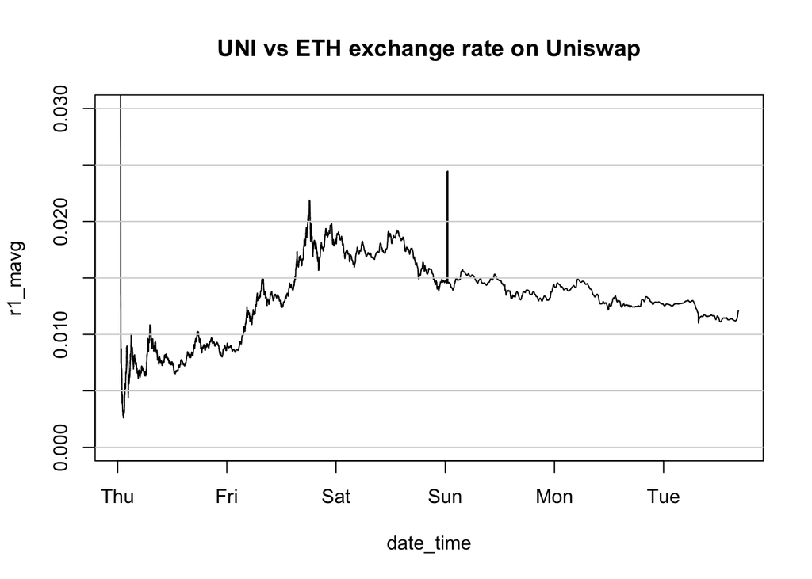

```r
for(i in 0:10) abline(h=i*0.005, col="lightgray")
```

```r
# simplify value as numeric in token
t[, value := as.numeric(value) / 1e18]

# keep only useful columns
t = t[, list(block_timestamp, value, from_address, to_address)]

# convert time
t[, date_time_str := substr(block_timestamp, 1, 16)]
#t[, date_time := strptime(date_time_str, "%Y-%m-%d %H:%M")]
t[, date_time := as.POSIXct(date_time_str, "%Y-%m-%d %H:%M", tz = "GMT")]

t = t[, list(date_time, value, from_address, to_address)]

t = t[order(date_time)]
```

## Total tokens exchanged by time

```r
tg = t[, list(value_exchanged = sum(value)), by=date_time]
#tg[, plot(date_time, value_exchanged, main="UNI tokens exchanged, over time")]
```

```r
t[, trx_count := 1:.N]
t = t[, list(trx_count, date_time, from_address, to_address, value)]
t[1:20, list(trx_count, date_time,
             from_address = paste0(substr(from_address, 1, 10), "..."),
             to_address = paste0(substr(to_address, 1, 10), "..."),
             value
             )]
```

```
##     trx_count           date_time  from_address    to_address      value
##  1:         1 2020-09-14 18:11:00 0x00000000... 0x41653c7d... 1.0000e+09
##  2:         2 2020-09-14 18:31:00 0x41653c7d... 0xe5737257... 2.0000e+00
##  3:         3 2020-09-14 18:35:00 0x41653c7d... 0xe5737257... 8.0000e+00
##  4:         4 2020-09-14 20:57:00 0xe5737257... 0x1c8bca22... 2.0000e+00
##  5:         5 2020-09-14 21:00:00 0xe5737257... 0x557847aa... 2.0000e+00
##  6:         6 2020-09-14 21:01:00 0xe5737257... 0x672f8518... 2.0000e+00
##  7:         7 2020-09-15 01:35:00 0x1c8bca22... 0x672f8518... 1.0000e-03
##  8:         8 2020-09-15 13:37:00 0x672f8518... 0x41653c7d... 2.0010e+00
##  9:         9 2020-09-15 14:53:00 0xe5737257... 0x41653c7d... 4.0000e+00
## 10:        10 2020-09-15 19:53:00 0x1c8bca22... 0x41653c7d... 1.9990e+00
## 11:        11 2020-09-15 23:23:00 0x557847aa... 0x6a452e53... 2.0000e+00
## 12:        12 2020-09-15 23:26:00 0x6a452e53... 0x41653c7d... 2.0000e+00
## 13:        13 2020-09-16 20:08:00 0x41653c7d... 0x090d4613... 1.5000e+08
## 14:        14 2020-09-16 20:08:00 0x41653c7d... 0x3032ab3f... 2.0000e+07
## 15:        15 2020-09-16 20:08:00 0x41653c7d... 0x8fdb3816... 4.0000e+08
## 16:        16 2020-09-16 20:09:00 0x41653c7d... 0x4750c438... 1.7200e+08
## 17:        17 2020-09-16 20:10:00 0x41653c7d... 0xe3953d9d... 1.2900e+08
## 18:        18 2020-09-16 20:10:00 0x41653c7d... 0x4b4e140d... 8.6000e+07
## 19:        19 2020-09-16 20:11:00 0x41653c7d... 0x3d30b1ab... 4.3000e+07
## 20:        20 2020-09-16 21:32:00 0x090d4613... 0xf94e5cdf... 1.4001e+03
```

```r
tgf = tg[value_exchanged < 1e6]
tgf[, value_mavg := frollmean(value_exchanged, 60)]
#tgf[, plot(date_time, value_exchanged, col="gray")]
#tgf[, lines(date_time, value_mavg, col="blue")]
```

```r
# top addresses by number of trades
top_to = t[, list(.N, total_tokens_to = sum(value)), by=to_address][order(-total_tokens_to)][N>10][1:5]
top_to$comment = c("Uniswap ETH-UNI pool", "Binance", "Huobi 10", "?","OKEx")
top_to
```

```
##                                    to_address      N total_tokens_to
## 1: 0xd3d2e2692501a5c9ca623199d38826e513033a17 116136        98508771
## 2: 0x3f5ce5fbfe3e9af3971dd833d26ba9b5c936f0be  29276        45340240
## 3: 0xe93381fb4c4f14bda253907b18fad305d799241a   8646        21273968
## 4: 0xe89a6d0509faf730bd707bf868d9a2a744a363c7    577         6869884
## 5: 0x6cc5f688a315f3dc28a7781717a9a798a59fda7b    764         4877839
##                 comment
## 1: Uniswap ETH-UNI pool
## 2:              Binance
## 3:             Huobi 10
## 4:                    ?
## 5:                 OKEx
```

```r
top_from = t[, list(.N, total_tokens_from = sum(value)), by=from_address][order(-total_tokens_from)][N>10][1:5]
top_from$comment = c("Uniswap", "Uniswap: Token Distributor", "Uniswap ETH-UNI pool", "Binance","Huobi 10")
top_from
```

```
##                                  from_address      N total_tokens_from
## 1: 0x8fdb3816fe10e16aaa9b12b3c4688c873efe2eca     84         400000000
## 2: 0x090d4613473dee047c3f2706764f49e0821d256e 187188         114777651
## 3: 0xd3d2e2692501a5c9ca623199d38826e513033a17  42709          92736326
## 4: 0x3f5ce5fbfe3e9af3971dd833d26ba9b5c936f0be   7194          22566587
## 5: 0xe93381fb4c4f14bda253907b18fad305d799241a   2342          10990342
##                       comment
## 1:                    Uniswap
## 2: Uniswap: Token Distributor
## 3:       Uniswap ETH-UNI pool
## 4:                    Binance
## 5:                   Huobi 10
```

```r
top_addresses_to = t[, .N, by=to_address][order(-N), to_address][1:5]
top_addresses_from = t[, .N, by=from_address][order(-N), from_address][1:5]
top_addresses = unique(c(top_addresses_to, top_addresses_from))
top_addresses
```

```
## [1] "0xd3d2e2692501a5c9ca623199d38826e513033a17"
## [2] "0x3f5ce5fbfe3e9af3971dd833d26ba9b5c936f0be"
## [3] "0xe93381fb4c4f14bda253907b18fad305d799241a"
## [4] "0x5ac13261c181a9c3938bfe1b649e65d10f98566b"
## [5] "0x7a250d5630b4cf539739df2c5dacb4c659f2488d"
## [6] "0x090d4613473dee047c3f2706764f49e0821d256e"
```

## Binance trades

We focus on Binance trades, and calculate the cumulative sum of tokens boughts, over time.

```r
binance_trades = t[(to_address=="0x3f5ce5fbfe3e9af3971dd833d26ba9b5c936f0be") | (from_address=="0x3f5ce5fbfe3e9af3971dd833d26ba9b5c936f0be")]
binance_trades[to_address=="0x3f5ce5fbfe3e9af3971dd833d26ba9b5c936f0be", value_dir := value]
binance_trades[from_address=="0x3f5ce5fbfe3e9af3971dd833d26ba9b5c936f0be", value_dir := - value]
bg = binance_trades[, list(value = sum(value_dir)), by=date_time][order(date_time)]
bg[, token_count := cumsum(value)]
```

```r
# Plot
## add extra space to right margin of plot within frame
par(mar=c(5, 4, 4, 6) + 1.5)
bg[, plot(date_time, token_count, col="black", type = "l", xlab="", ylab="", #axes=FALSE,
          main="Binance UNI tokens held",las=1)]
```

```r
#axis(2, ylim=c(0,1),col="black",las=1)  ## las=1 makes horizontal labels
mtext("Binance UNI token holdings",side=2,line=4)
box()
abline(h=0)

## Allow a second plot on the same graph
par(new=TRUE)
s[!is.na(r1_mavg), plot(date_time, r1_mavg, xlab="", ylab="",
                        ylim=c(0, 0.03),
                        type="l",
                        col = "red", axes=FALSE)]
```

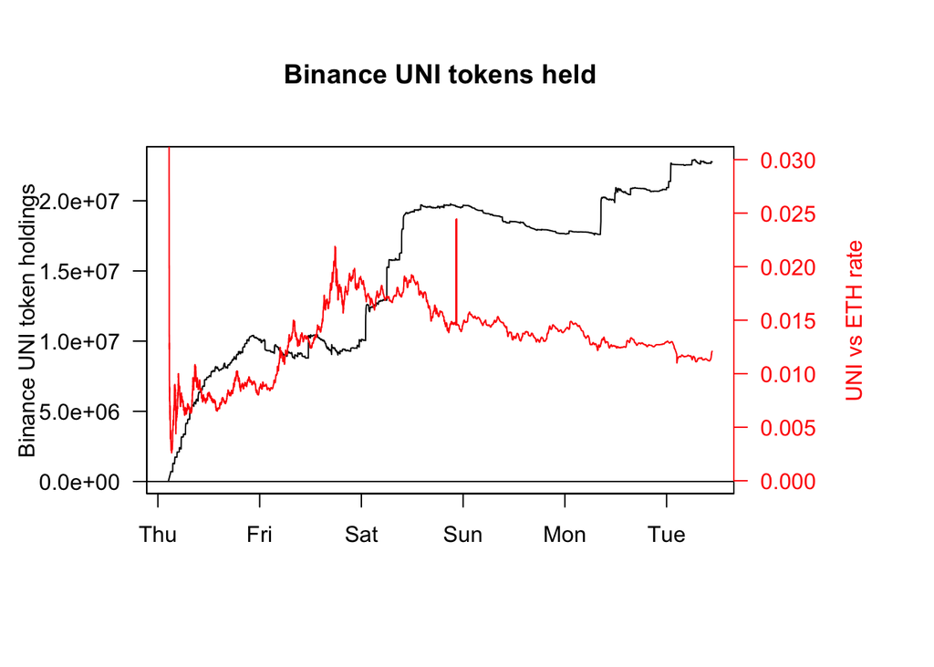

```r
mtext("UNI vs ETH rate", side=4, col="red", line=4)
axis(4, col="red",col.axis="red",las=1)
```

## Huobi trades

```r
huobi_trades = t[(to_address=="0xe93381fb4c4f14bda253907b18fad305d799241a") | (from_address=="0xe93381fb4c4f14bda253907b18fad305d799241a")]
huobi_trades[to_address=="0xe93381fb4c4f14bda253907b18fad305d799241a", value_dir := value]
huobi_trades[from_address=="0xe93381fb4c4f14bda253907b18fad305d799241a", value_dir := - value]
hg = huobi_trades[, list(value = sum(value_dir)), by=date_time][order(date_time)]
hg[, token_count := cumsum(value)]
```

```r
# Plot
## add extra space to right margin of plot within frame
par(mar=c(5, 4, 4, 6) + 1.5)
hg[, plot(date_time, token_count, col="black", type = "l", xlab="", ylab="", #axes=FALSE,
          main="Huobi UNI tokens held",las=1)]
```

```r
#axis(2, ylim=c(0,1),col="black",las=1)  ## las=1 makes horizontal labels
mtext("Huobi UNI token holdings",side=2,line=4)
box()
abline(h=0)

## Allow a second plot on the same graph
par(new=TRUE)
s[!is.na(r1_mavg), plot(date_time, r1_mavg, xlab="", ylab="",
                        ylim=c(0, 0.03),
                        type="l",
                        col = "red", axes=FALSE)]
```

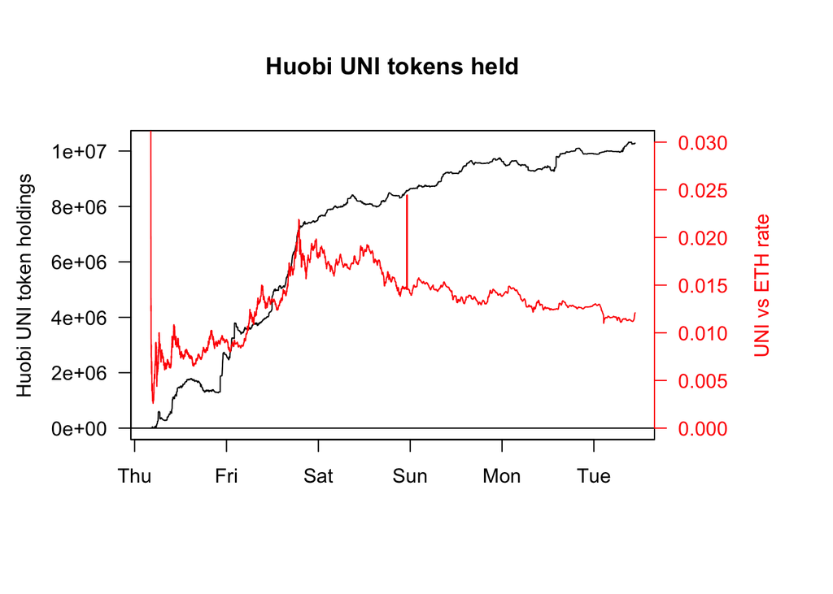

```r
mtext("UNI vs ETH rate", side=4, col="red", line=4)
axis(4, col="red",col.axis="red",las=1)
```